# Interlab study

Test run

Hugo Pineda Hernandez

November 04 2021

# 1 Plate reader data

## 1.1 Plate reader raw data

### 1.1.1 OD<sub>730</sub>

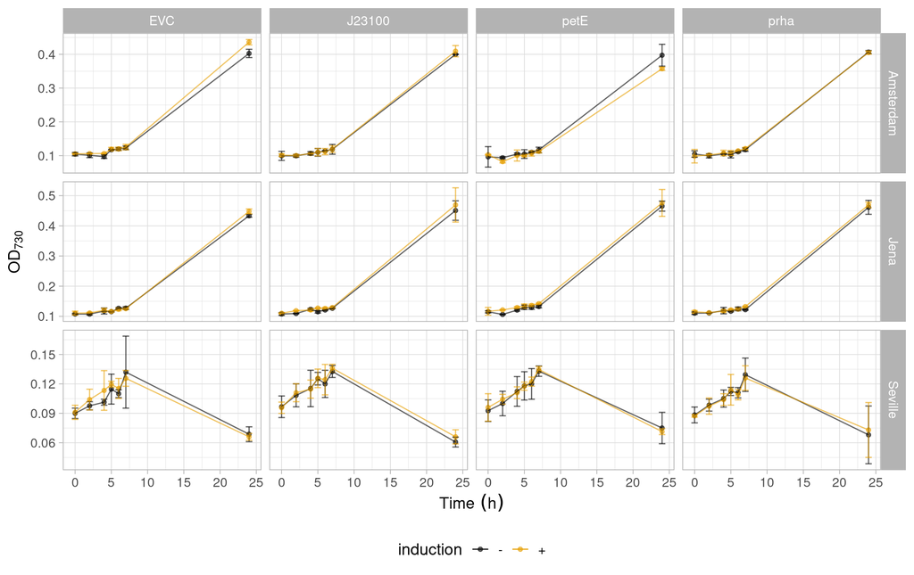

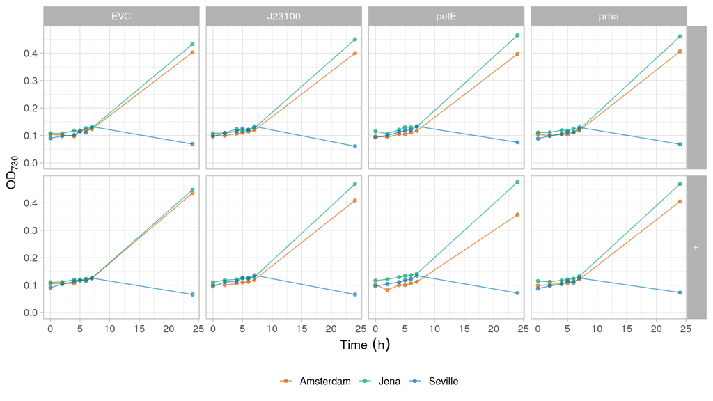

### 1.1.2 Fluorescence

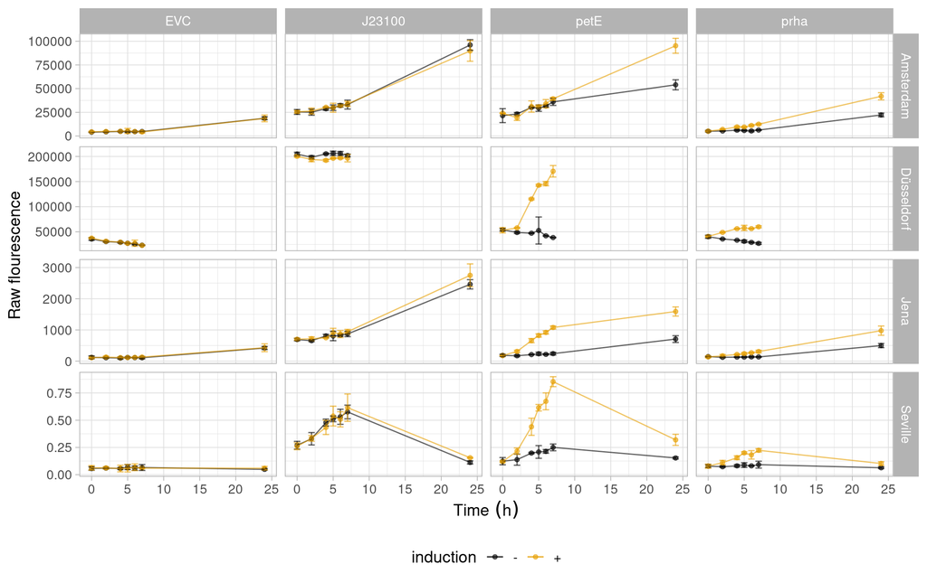

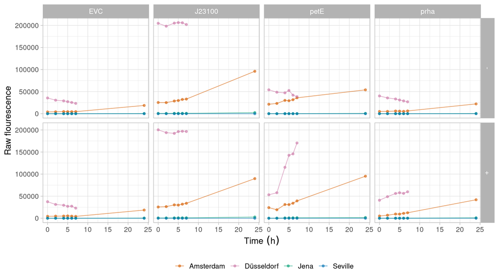

## 1.2 Plate reader data normalization

- Step 1, background OD<sub>730</sub> correction:
  - Calculate average OD<sub>730</sub> of blank wells for each timepoint
  - Subtract blank average OD<sub>730</sub> from the rest of the wells for each timepoint
- Step 2, EVC normalization:
  - For each timepoint, calculate the average raw fluorescence / OD<sub>730</sub> of ALL the EVC wells
  - For each timepoint, calculate raw fluorescence / OD<sub>730</sub> for each well
  - For each timepoint, subtract the average EVC fluorescence / OD<sub>730</sub> from the fluorescence / OD<sub>730</sub> of each well

This step corrects for autofluorescence and background fluorescence at the same time and it also normalizes for the biomass.

- Step 3, summarize:
  - Take the average of the background corrected fluorescence / OD<sub>730</sub> caculated in the previous step, for each experiment, strain, condition and timepoint.
- Step 4, 0 to 1 normalization:
  - For each experiment, normalize the average ratios calculated previously from 0 to 1 by using the min max method: $\frac{\frac{F}{OD_{730}} - min(\frac{F}{OD_{730}})}{ max(\frac{F}{OD_{730}}) - min(\frac{F}{OD_{730}})}$

This step allows to compare the ratios between labs.

### 1.2.1 Results after step 3

Mind the different scales in Y-axis.

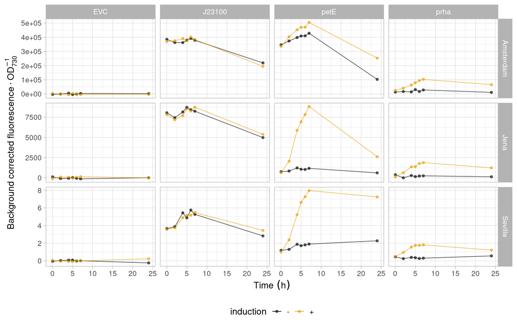

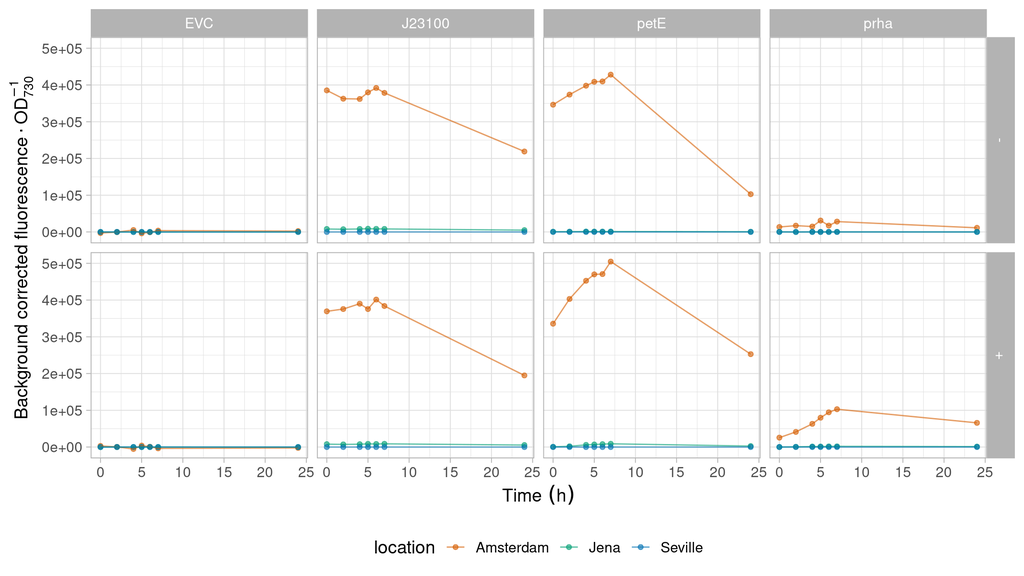

### 1.2.2 Results after step 4

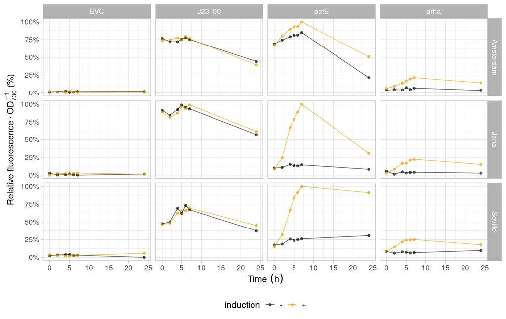

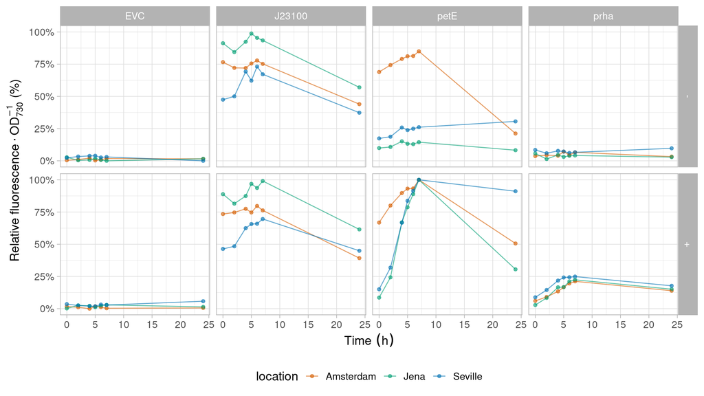